# Hedging

```python
import numpy
from statsmodels import regression
import statsmodels.api as sm
import matplotlib.pyplot as plt
```

```python
start = '2008-09-15'
end = '2009-09-15'
```

```python
asset = get_pricing('AAPL', fields='price', start_date=start, end_date=end)
```

```python
benchmark = get_pricing('SPY', fields='price', start_date=start, end_date=end)
```

```python
Rp =  asset.pct_change(1)[1:]
Rm = benchmark.pct_change(1)[1:]
```

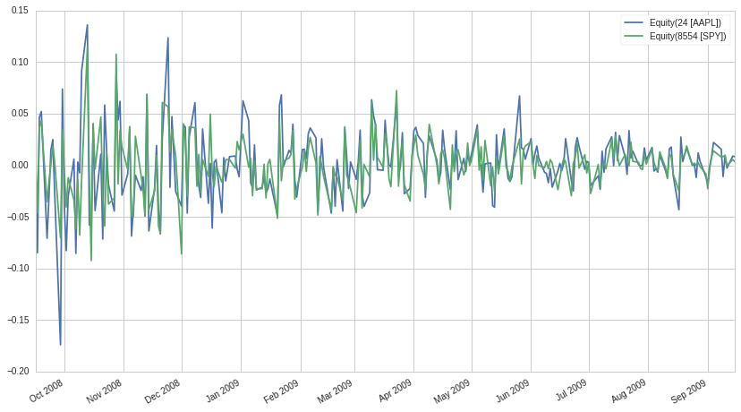

```python
Rp.plot()
Rm.plot()
plt.legend()
```

```
(733316.0, 733345.0)
```

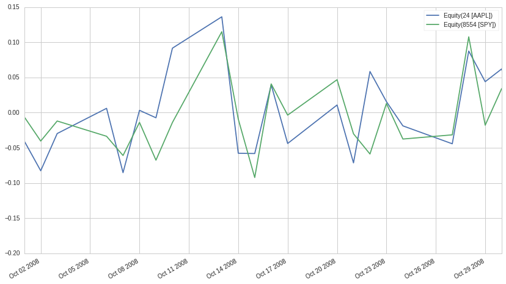

```python
Rp.plot()
Rm.plot()
plt.legend()
plt.xlim(['2008-10-01','2008-10-30'])  # we can see the work of beta on oct14th in the plot
```

# what is alpha of a stock?

"Alpha" (α) is a term used in investing to describe a strategy's ability to beat the market, or it's "edge." Alpha is thus also often referred to as “excess return” or “abnormal rate of return,” which refers to the idea that markets are efficient, and so there is no way to systematically earn returns that exceed the broad market as a whole. Alpha is often used in conjunction with beta (β) , which measures the broad market's overall volatility or risk, known as systematic market risk.

Alpha is used in finance as a measure of performance, indicating when a strategy, trader, or portfolio manager has managed to beat the market return over some period. Alpha, often considered the active return on an investment, gauges the performance of an investment against a market index or benchmark that is considered to represent the market’s movement as a whole.

`The excess return of an investment relative to the return of a benchmark index is the investment’s alpha.`

Alpha may be positive or negative and is the result of active investing. Beta, on the other hand, can be earned through passive index investing.

# what is beta of a stock?

Beta measures how an asset / security/ portfolio is correlated with the market, Beta describes the activity of a security's returns responding to swings in the market.

A security's beta is calculated by dividing the product of the covariance of the security's returns and the market's returns by the variance of the market's returns over a specified period.

The beta help investors understand whether a stock moves in the same direction as the rest of the market, and how volatile or risky it is compared to the market

when a stock has a 𝛽 of 0 it means that it is not correlated with the market at all but not neccessarily underperforming, 𝛽 of 1 means a perfect correlation with the benchmark. 𝛽 of -1 means the stock is inversly correlated with the market i.e it swings in the opposite direction of the market most of the time.

e.g gold miners and S&P500

if a stock has 𝛽 >1 or 𝛽<-1 it means that the stock moves in the direction of the market but it is highly volatile.

Limitations of Beta While beta offers useful information for stock evaluation, it does have a few shortcomings. Beta is useful in determining a security's short-term risk, and for analyzing volatility to arrive at equity costs using CAPM. However, the since beta statistic is calculated using historical data points, it becomes less meaningful for investors looking to predict a stock's future movements.

Additionally, because beta relies on historical data, it doesn't factor in any new information on the market, stock or portfolio for which it's used. Beta is also less useful for long-term investments since a stock's volatility can change significantly from year to year depending upon the company's growth stage and other factors.

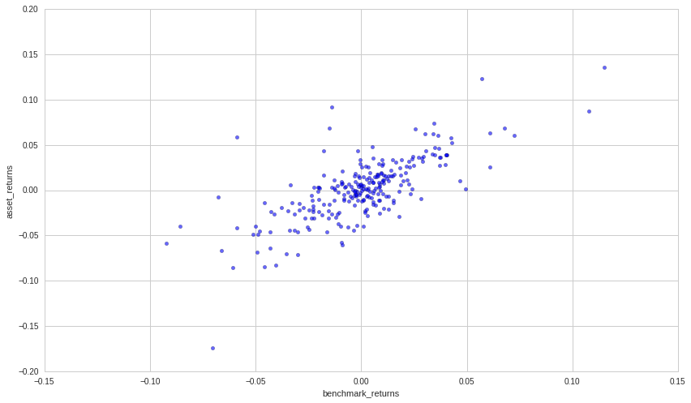

```python
plt.scatter(Rm, Rp,alpha=.6)
plt.ylabel('asset_returns')
plt.xlabel('benchmark_returns')
```

# linear regression with statsmodels

```python
Rm_constant = sm.add_constant(Rm)
reg = regression.linear_model.OLS(Rp,Rm_constant).fit()
```

```python
alpha, beta = reg.params
```

```python
alpha
```

```
0.0015036169028564744
```

```python
beta
```

```
0.92615289919884036
```

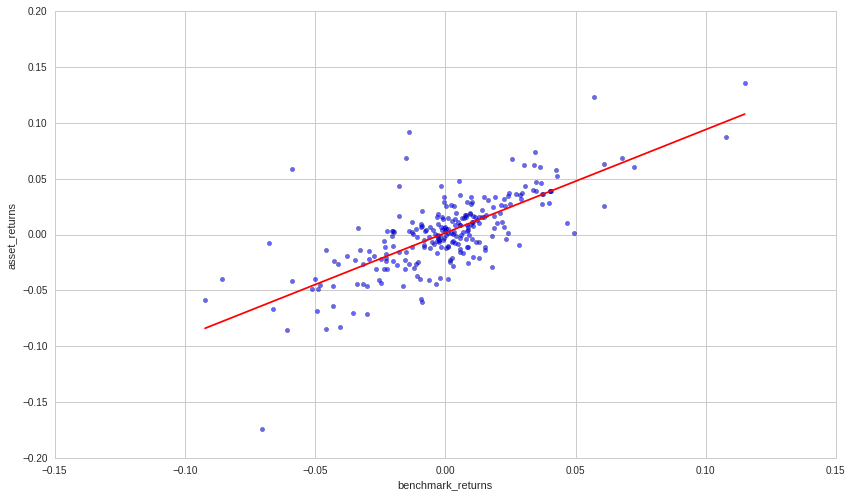

```python
plt.scatter(Rm, Rp,alpha=.6)
plt.ylabel('asset_returns')
plt.xlabel('benchmark_returns')
x_window = numpy.linspace(Rm.values.min(), Rm.values.max(),100)
y = x_window*beta + alpha
plt.plot(x_window,y,'r')
```

# our hedge portfolio is = -1(beta*Rm)+Rp

```python
hedge_portfolio = -1*(beta*Rm)+Rp
```

```
(733330.0, 733391.0)
```

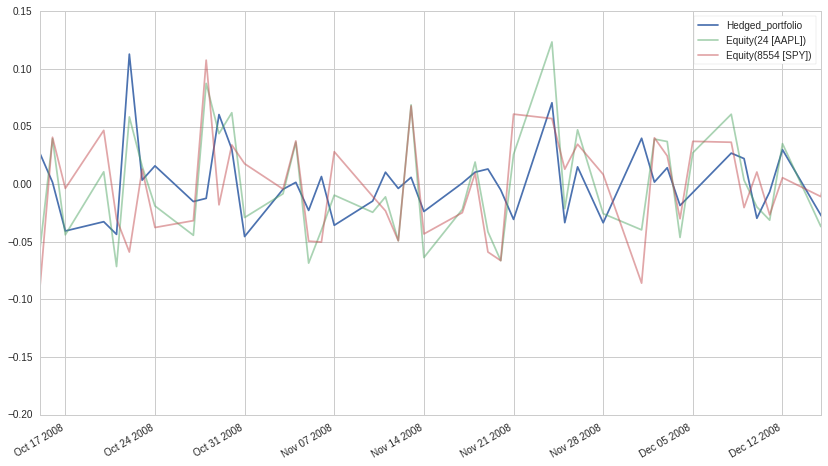

```python
hedge_portfolio.plot(label='Hedged_portfolio')
Rp.plot(alpha=0.5)
Rm.plot(alpha=0.5)
plt.legend()
plt.xlim(['2008-10-15','2008-12-15'])
```

`we can see that during the start of Dec SPY dips very much but Hedge does not. the portfolio as a whole is hedged against the swings of the market`

`we are sacrificing the returns for volatility`

# let's see the effects of hedging in action

```python
def alpha_beta(market_returns ,portfolio_returns):
    market_constant = sm.add_constant(market_returns)
    reg = regression.linear_model.OLS(portfolio_returns,market_constant).fit() # OLS(y,X)
    alpha, beta = reg.params
    return alpha, beta
```

# alpha beta of the unhedged portfolio

```python
start = '2008-09-15'
end = '2010-09-15'

asset = get_pricing('AAPL', fields='price', start_date=start, end_date=end)
benchmark = get_pricing('SPY', fields='price', start_date=start, end_date=end)
Rp =  asset.pct_change(1)[1:]
Rm = benchmark.pct_change(1)[1:]

alpha_unhedged, beta_unhedged = alpha_beta(Rm.values, Rp.values)
```

# Hedged portfolio

```python
hedged_portfolio_returns = Rp-beta_unhedged*Rm
alpha_hedged, beta_hedged = alpha_beta(Rm.values, hedged_portfolio_returns.values)
```

```python
beta_unhedged
```

```
0.94473474058363216
```

```python
beta_hedged # almost 0
```

```
4.163336342344337e-16
```

```python
alpha_unhedged
```

```
0.0014973855396783085
```

```python
alpha_hedged
```

```
0.0014973855396783094
```

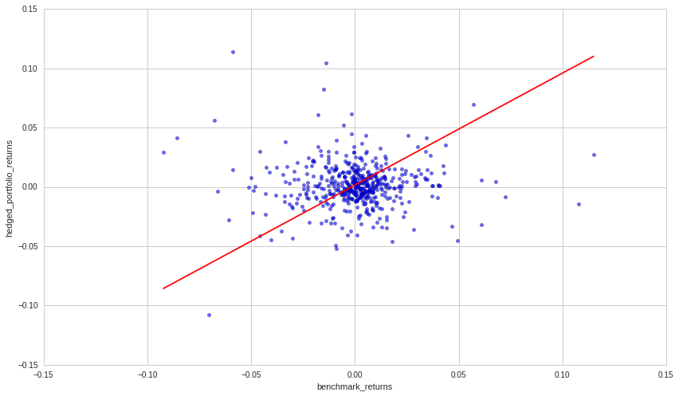

```python
plt.scatter(Rm, hedged_portfolio_returns,alpha=.6)
plt.ylabel('hedged_portfolio_returns')
plt.xlabel('benchmark_returns')
x_window = numpy.linspace(Rm.values.min(), Rm.values.max(),100)
y = x_window*beta_unhedged + alpha
plt.plot(x_window,y,'r')
```

# hedge effectively reduces volatility but at a cost of overall returns

```python
hedged_portfolio_returns.mean()
```

```
0.0014973855396783092
```

```python
Rp.mean()
```

```
0.001675375972521026
```

we see a 2 pip down in returns on account of hedging

```python
hedged_portfolio_returns.std()
```

```
0.018961266649916646
```

```python
Rp.std()
```

```
0.027470543841313044
```

`we see a reduction in volatility`

Reference: Investopedia, wikipedia